# Recurrent Neural Network (RNN)

Una red neuronal recurrente es un tipo de red neuronal que analiza secuencias de datos o redes de tiempo. Es decir, considera datos donde una entrada depende de las entradas anteriores. A diferencia de las redes neuronales clasicas y las CNN, las RNN son capaces de manejar entradas de diferente dimension, ademas del hecho de que a diferencia de una red neuronal clasica, permite compartir las caracteristicas aprendidas a partir de diferentes posiciones de la secuencia. A continuacion se muestran 2 de las posibles arquitecturas de una RNN.

[figure not shown]

Como vemos en la imagen, a diferencia de una red neuronal clasica donde para cada entrada obtenemos una salida, pero no se comparte conocimiento referente a lo obtenido en una entrada cualquiera. En una RNN parte de la informacion que se obtiene al procesar una entrada es considerada durante el procesamiento de la siguiente entrada, donde:

- $x_t \in \mathbb{R}$ is the input at time step $t$. To keep things simple, we assume that $x_t$ is a scalar value with a single feature. You can extend this idea to a $d$-dimensional feature vector.
- $y_t \in \mathbb{R}$ is the output of the network at time step . We can produce multiple outputs in the network, but for this example, we assume that there is one output
- $h_t \in \mathbb{R}^m$ vector stores the values of the hidden units/states at time $t$. This is also called the **current context**. $m$ is the number of hidden units. $h_0$vector is initialized to zero. *Segun entendi, $h_t$ es la salida de las funciones de activacion de las diferentes neuronas de la capa en el tiempo $t$.*
- $w_x \in \mathbb{R}^m$ are weights associated with inputs in the recurrent layer. *Se utiliza el mismo $w_x$ en cada capa recurrente, sin importar el tiempo $t$.*
- $w_h \in \mathbb{R}^{m \times m}$ are weights associated with hidden units in the recurrent layer. *Segun entendi, $w_h$ podemos interpretarlo como los pesos que cada neurona de la capa actual le asigna a cada una de las salidas de la funcion de activacion ($h_t$) de la capa anterior, es decir, en el tiempo $t-1$. Se utiliza el mismo $w_h$ en cada capa recurrente, sin importar el tiempo $t$.*
- $w_y \in \mathbb{R}^m$ are weights associated with hidden units to output units. *Segun entendi, $w_y$ podemos interpretarlo como los pesos que tiene para la salida, no para las neuronas de la capa actual, la salida de la funcion de activacion de la capa anterior, o lo que es lo mismo en el tiempo $t-1$. Se utiliza el mismo $w_y$ en cada capa recurrente, sin importar el tiempo $t$.*
- $b_h \in \mathbb{R}^m$ is the bias associated with the recurrent layer. *Es decir, es el bias a partir del cual se calcula la salida de la funcion de activacion de cada una de las neuronas en la capa actual. $b_h$ es el mismo para cada capa.*
- $b_y \in \mathbb{R}$ is the bias associated with the feedforward layer. *Es decir, es el bias que se usa para calcular la salida de la capa actual, ojo, para la salida de la capa actual, no para la salida de la funcion de activacion de la capa actual. $b_y$ es el mismo para cada capa.*

# Forward pass

Las siguientes ecuaciones describen el proceso de propagacion hacia adelante en una RNN. Lo cual explica la relacion entre las variables antes mecionadas:

$h_t = f(x_t, h_t, w_x, w_h, b_h) = f(x_t \cdot w_x + h_{t-1} \cdot w_h + b_h)$, y de ahí:  
$y_t = f(h_t, w_y) = f(h_t \cdot w_y + b_y)$

**OJO:** La funcion de activacion $f$ no tiene que ser la misma para $h_t$ y $y_t$, incluso rara vez lo es. Incluso, en el caso de $h_t$ usualmente se suele usar **RELU** y **tanh** como funciones de activacion. Mientras que en el caso de $y_t$ la funcion de activacion suele ser **softmax** y **sigm**.

[figure not shown]

# Backward pass

Primero se propaga el error a traves de $y_t$ y luego de $h_{t+1}$. Ademas, a fin de realizar una propagacion del error, tenemos que calcular dicho error. Para ello tenemos que calcular la diferencia entre el valor predicho y el esperado utilizando alguna funcion de costo. Por ejemplo, utilizando **cross-entropy** el costo para una determinada salida $y^{pred}$ en un tiempo $t$ seria:

$L_t(y_t^{pred}, y_t^{true}) = - y_t^{true} \cdot \log( y_t^{pred}) - (1 - y_t^{true}) \cdot \log( 1 - y_t^{pred})$

y considerando que tenemos $T_x$ tiempos o lo que es lo mismo entradas, el costo total seria:  
$L = \sum_{t = 1}^{T_x} L_t(y_t^{pred}, y_t^{true})$

# Tangente hiperbolica

La funcion de activacion tangente hiperbolica se define como: $$tanh = \frac{e^x - e^{-x}}{e^x + e^{-x}}$$

# Ejemplo 1

```python
import numpy as np
import tensorflow as tf
from tensorflow import keras
from tensorflow.keras import layers
```

Generamos un conjunto de datos de numeros flotantes con 32 filas, 10 columnas y 8 subcolumnas por cada columna.

```python
inputs = np.random.random([32, 10, 8]).astype(np.float32)
inputs.shape
```

```
(32, 10, 8)
```

```python
inputs[3,:,:]
```

```
array([[0.4070065 , 0.8896648 , 0.81957793, 0.4020825 , 0.7419898 ,
        0.18621309, 0.33287525, 0.7357225 ],
       [0.81426406, 0.29469994, 0.3340006 , 0.84657156, 0.30995393,
        0.77272683, 0.20382638, 0.74945015],
       [0.8223017 , 0.5213581 , 0.10462426, 0.88082844, 0.43397206,
        0.91504693, 0.54712915, 0.40296543],
       [0.19270132, 0.33252874, 0.39385745, 0.26135954, 0.7569539 ,
        0.91320807, 0.8164365 , 0.62216675],
       [0.951092  , 0.90217537, 0.71958417, 0.35045484, 0.01913104,
        0.81338584, 0.42093435, 0.3683841 ],
       [0.17071505, 0.23515086, 0.82480866, 0.12671651, 0.4172559 ,
        0.41402528, 0.0154671 , 0.17722414],
       [0.9021472 , 0.40257013, 0.20666333, 0.05579093, 0.31228483,
        0.7916251 , 0.9598759 , 0.64904255],
       [0.17305622, 0.84087646, 0.96802306, 0.19852792, 0.660291  ,
        0.32950756, 0.11311412, 0.17253354],
       [0.9164493 , 0.79244   , 0.08561972, 0.41376713, 0.9890838 ,
        0.94406825, 0.914312  , 0.24583103],
       [0.38735184, 0.8581216 , 0.495682  , 0.6774171 , 0.18718487,
        0.9797466 , 0.33177274, 0.79066986]], dtype=float32)
```

Creamos una capa neuronal recurrente de 4 neuronas, por lo que a su vez obtendremos ese mismo numero de salidas.

```python
simple_rnn = tf.keras.layers.SimpleRNN(4)
```

Obtenemos la salida de la capa

```python
output = simple_rnn(inputs)
output.shape
```

```
TensorShape([32, 4])
```

Tambien podemos usar los parametros **return_sequences** y **return_state** para retornar la ultima salida en la ultima secuencia de salida y el ultimo estado respectivamente.

```python
simple_rnn = tf.keras.layers.SimpleRNN(4, return_sequences=True, return_state=True)
```

```python
# whole_sequence_output has shape `[32, 10, 4]`.
# final_state has shape `[32, 4]`.
whole_sequence_output, final_state = simple_rnn(inputs)
whole_sequence_output.shape, final_state.shape
```

```
(TensorShape([32, 10, 4]), TensorShape([32, 4]))
```

```python
whole_sequence_output[3,:,:]
```

```
<tf.Tensor: shape=(10, 4), dtype=float32, numpy=
array([[-0.68440056,  0.46755937,  0.01805103, -0.19661747],
       [-0.5438615 ,  0.45101663, -0.11780576,  0.6261221 ],
       [-0.27797255,  0.6958761 , -0.6348162 ,  0.26410097],
       [-0.6945754 , -0.20148787, -0.9054739 , -0.08109827],
       [-0.9747621 ,  0.89350027,  0.43181825,  0.8953192 ],
       [ 0.14868014, -0.33520335, -0.85544205,  0.604572  ],
       [-0.92495114,  0.8943724 , -0.5431643 , -0.20639314],
       [-0.84753776, -0.4716176 , -0.47462502,  0.79109913],
       [-0.6062929 ,  0.92445815, -0.76536727,  0.33101448],
       [-0.861946  ,  0.15179694, -0.6704058 ,  0.5514135 ]],
      dtype=float32)>
```

# Ejemplo

Este ejemplo fue tomado de https://machinelearningmastery.com/understanding-simple-recurrent-neural-networks-in-keras/

```python
from pandas import read_csv
import numpy as np
from keras.models import Sequential
from keras.layers import Dense, SimpleRNN
from sklearn.preprocessing import MinMaxScaler
from sklearn.metrics import mean_squared_error
import math
import matplotlib.pyplot as plt
```

### Analisis descriptivo

```python
sunspots_url = 'https://raw.githubusercontent.com/jbrownlee/Datasets/master/monthly-sunspots.csv'
df = read_csv(sunspots_url)
df.head()
```

|  | Month | Sunspots |
| --- | --- | --- |
| 0 | 1749-01 | 58.0 |
| 1 | 1749-02 | 62.6 |
| 2 | 1749-03 | 70.0 |
| 3 | 1749-04 | 55.7 |
| 4 | 1749-05 | 85.0 |

```python
df.describe()
```

|  | Sunspots |
| --- | --- |
| count | 2820.000000 |
| mean | 51.265957 |
| std | 43.448971 |
| min | 0.000000 |
| 25% | 15.700000 |
| 50% | 42.000000 |
| 75% | 74.925000 |
| max | 253.800000 |

### Construccion del modelo

The function below returns a model that includes a SimpleRNN layer and a Dense layer for learning sequential data. The input_shape specifies the parameter (time_steps x features). We’ll simplify everything and use univariate data, i.e., one feature only; the time steps are discussed below.

```python
def create_RNN(hidden_units, dense_units, input_shape, activation):
    model = Sequential()
    model.add(SimpleRNN(hidden_units, input_shape = input_shape, activation = activation[0]))
    model.add(Dense(units = dense_units, activation = activation[1]))
    model.compile(loss='mean_squared_error', optimizer='adam')
    return model

demo_model = create_RNN(2, 1, (3,1), activation=['linear', 'linear'])
```

The object demo_model is returned with two hidden units created via the SimpleRNN layer and one dense unit created via the Dense layer. The input_shape is set at 3×1, and a linear activation function is used in both layers for simplicity. Just to recall, the linear activation function makes no change in the input. The network looks as follows:

```python
demo_model.summary()
```

```
Model: "sequential"
_________________________________________________________________
 Layer (type)                Output Shape              Param #
=================================================================
 simple_rnn_2 (SimpleRNN)    (None, 2)                 8

 dense (Dense)               (None, 1)                 3

=================================================================
Total params: 11
Trainable params: 11
Non-trainable params: 0
_________________________________________________________________
```

```python
wx = demo_model.get_weights()[0]
wh = demo_model.get_weights()[1]
bh = demo_model.get_weights()[2]
wy = demo_model.get_weights()[3]
by = demo_model.get_weights()[4]

print('wx = ', wx, ' wh = ', wh, ' bh = ', bh, ' wy =', wy, 'by = ', by)
```

```
wx =  [[ 1.047315  -1.2990991]]  wh =  [[-0.2250154 -0.9743552]
 [-0.9743552  0.2250154]]  bh =  [0. 0.]  wy = [[-0.8842149]
 [-0.7020458]] by =  [0.]
```

```python
x = np.array([1, 2, 3])
# Reshape the input to the required sample_size x time_steps x features
x_input = np.reshape(x,(1, 3, 1))
y_pred_model = demo_model.predict(x_input)


m = 2
h0 = np.zeros(m)
h1 = np.dot(x[0], wx) + h0 + bh
h2 = np.dot(x[1], wx) + np.dot(h1,wh) + bh
h3 = np.dot(x[2], wx) + np.dot(h2,wh) + bh
o3 = np.dot(h3, wy) + by

print('h1 = ', h1,'h2 = ', h2,'h3 = ', h3)

print("Prediction from network ", y_pred_model)
print("Prediction from our computation ", o3)
```

```
h1 =  [[ 1.047315   -1.29909909]] h2 =  [[ 3.12475198 -3.91097232]] h3 =  [[ 6.24950398 -7.82194467]]
Prediction from network  [[-0.03454065]]
Prediction from our computation  [[-0.03454101]]
```

```python
def get_train_test(url, split_percent=0.8):
    df = read_csv(url, usecols=[1], engine='python')
    data = np.array(df.values.astype('float32'))
    scaler = MinMaxScaler(feature_range=(0, 1))
    data = scaler.fit_transform(data).flatten()
    n = len(data)
    # Point for splitting data into train and test
    split = int(n*split_percent)
    train_data = data[range(split)]
    test_data = data[split:]
    return train_data, test_data, data

train_data, test_data, data = get_train_test(sunspots_url)
```

```python
train_data
```

```
array([0.22852638, 0.24665089, 0.2758077 , ..., 0.3506698 , 0.4546887 ,
       0.4862096 ], dtype=float32)
```

The next step is to prepare the data for Keras model training. The input array should be shaped as: total_samples x time_steps x features.

There are many ways of preparing time series data for training. We’ll create input rows with non-overlapping time steps. An example for time steps = 2 is shown in the figure below. Here, time steps denotes the number of previous time steps to use for predicting the next value of the time series data.

[figure not shown]

```python
# Prepare the input X and target Y
def get_XY(dat, time_steps):
    # Indices of target array, data.shape is (2256,)
    Y_ind = np.arange(time_steps, len(dat), time_steps) #Y_ind.shape is (187,) and start at 12 with step of 12
    Y = dat[Y_ind]

    # Prepare X
    rows_x = len(Y) #187
    X = dat[range(time_steps*rows_x)]
    X = np.reshape(X, (rows_x, time_steps, 1))
    print(f"X[0].shape {X[0].shape}")
    return X, Y

time_steps = 12
trainX, trainY = get_XY(train_data, time_steps)
print(f"trainX.shape {trainX.shape} trainY.shape {trainY.shape}")
testX, testY = get_XY(test_data, time_steps)
print(f"testX.shape {testX.shape} testY.shape {testY.shape}")
```

```
X[0].shape (12, 1)
trainX.shape (187, 12, 1) trainY.shape (187,)
X[0].shape (12, 1)
testX.shape (46, 12, 1) testY.shape (46,)
```

```python
model = create_RNN(hidden_units=3, dense_units=1, input_shape=(time_steps,1),
                   activation=['tanh', 'tanh'])
model.fit(trainX, trainY, epochs=20, batch_size=1, verbose=2)
```

```
187/187 - 1s - loss: 0.0158 - 1s/epoch - 6ms/step
187/187 - 0s - loss: 0.0086 - 432ms/epoch - 2ms/step
187/187 - 0s - loss: 0.0071 - 455ms/epoch - 2ms/step
187/187 - 0s - loss: 0.0058 - 432ms/epoch - 2ms/step
187/187 - 0s - loss: 0.0050 - 432ms/epoch - 2ms/step
187/187 - 0s - loss: 0.0046 - 439ms/epoch - 2ms/step
187/187 - 0s - loss: 0.0044 - 432ms/epoch - 2ms/step
187/187 - 0s - loss: 0.0042 - 439ms/epoch - 2ms/step
187/187 - 0s - loss: 0.0040 - 479ms/epoch - 3ms/step
187/187 - 0s - loss: 0.0040 - 470ms/epoch - 3ms/step
187/187 - 0s - loss: 0.0041 - 470ms/epoch - 3ms/step
187/187 - 0s - loss: 0.0038 - 464ms/epoch - 2ms/step
187/187 - 0s - loss: 0.0037 - 470ms/epoch - 3ms/step
187/187 - 0s - loss: 0.0038 - 432ms/epoch - 2ms/step
187/187 - 0s - loss: 0.0037 - 486ms/epoch - 3ms/step
187/187 - 0s - loss: 0.0037 - 454ms/epoch - 2ms/step
187/187 - 0s - loss: 0.0037 - 432ms/epoch - 2ms/step
187/187 - 0s - loss: 0.0036 - 455ms/epoch - 2ms/step
187/187 - 0s - loss: 0.0036 - 432ms/epoch - 2ms/step
187/187 - 0s - loss: 0.0034 - 455ms/epoch - 2ms/step
```

```
<keras.callbacks.History at 0x16cebe1ee20>
```

```python
def print_error(trainY, testY, train_predict, test_predict):
    # Error of predictions
    train_rmse = math.sqrt(mean_squared_error(trainY, train_predict))
    test_rmse = math.sqrt(mean_squared_error(testY, test_predict))
    # Print RMSE
    print('Train RMSE: %.3f RMSE' % (train_rmse))
    print('Test RMSE: %.3f RMSE' % (test_rmse))

# make predictions
train_predict = model.predict(trainX)
test_predict = model.predict(testX)
# Mean square error
print_error(trainY, testY, train_predict, test_predict)
```

```
Train RMSE: 0.059 RMSE
Test RMSE: 0.087 RMSE
```

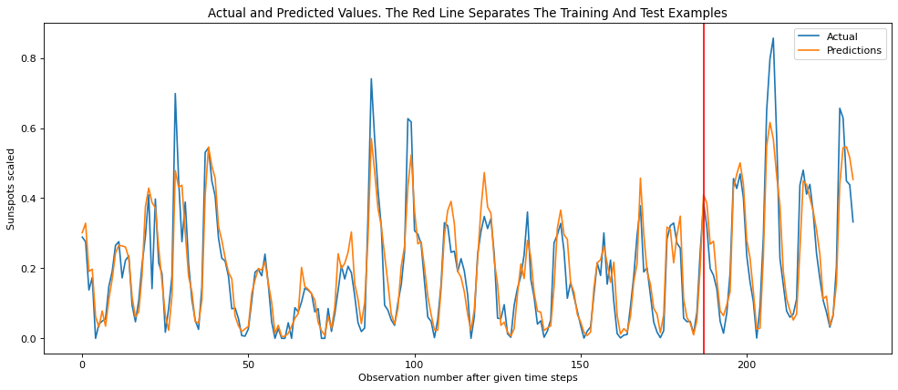

```python
# Plot the result
def plot_result(trainY, testY, train_predict, test_predict):
    actual = np.append(trainY, testY)
    predictions = np.append(train_predict, test_predict)
    rows = len(actual)
    plt.figure(figsize=(15, 6), dpi=80)
    plt.plot(range(rows), actual)
    plt.plot(range(rows), predictions)
    plt.axvline(x=len(trainY), color='r')
    plt.legend(['Actual', 'Predictions'])
    plt.xlabel('Observation number after given time steps')
    plt.ylabel('Sunspots scaled')
    plt.title('Actual and Predicted Values. The Red Line Separates The Training And Test Examples')
plot_result(trainY, testY, train_predict, test_predict)
```

Como vimos, en cada tiempo $t$ las RNN hacen uso de una variable $h_{t-1}$ la cual almacena el contexto del tiempo anterior, a partir del cual se calcula el contexto $h_t$ y la salida de la capa recurrente en el tiempo $t$. Sin embargo, en el tiempo $t + 1$, ya no se consideraria $h_{t-1}$. Lo cual resulta un inconveniente pues en muchas ocasiones un contexto en 2 o mas tiempos atras resulta de mayor utilidad que el contexto anterior, como por ejemplo para el autocompletado de texto. Ademas, en secuencias de procesamiento lo suficientemente grandes, el gradiente suele desvanecerse al hacer backpropagation, por lo que las primeras capas casi no se entrenaran. En estos casos es de gran utilidad hacer uso de las Long-short Term Memory (LSTM) y las Gate Recurrente Unit (GRU).

[figure not shown]

# GRU

Las **GRU** hacen uso de una celda de memoria $c$, en la cual se almacena el contexto de mayor importancia en cada momento, es decir, en un tiempo $t$, se decide si es mejor almacenar el contexto anterior que se poseia en esta variable $c$, o resulta mas adecuado reemplazar el valor de la misma por un contexto candidato $\hat{c}$.

Para cada capa recurrente, inicialmente $c_t = h_t$, luego se calcula un candidato $\hat{c}_t = m(x_t \cdot w_x + c_{t-1} \cdot w_c + b_c)$, donde $m$ es una funcion de activacion, por ejemplo la tangente hiperbolica, $w_c$ son los pesos asociados al contexto y $b_c$ el bias (ver el producto Hadamard https://en.wikipedia.org/wiki/Hadamard_product_(matrices)). Luego, se calcula una compuerta $\Gamma_u$, la cual haciendo uso de la funcion sigmoide toma valores 1 o 0, para indicar si se actualiza o no $c$, de forma tal que $\Gamma_u = \sigma(x_t \cdot w_x + c_{t-1} \cdot w_u + b_u)$ y finalmente $c_t = \Gamma_u \cdot \hat{c}_t + (1 - \Gamma_u) \cdot c_{t-1}$. Para mas informacion visita https://towardsdatascience.com/illustrated-guide-to-lstms-and-gru-s-a-step-by-step-explanation-44e9eb85bf21

[figure not shown]

# Ejemplo

El ejemplo fue tomado de https://pythonalgos.com/build-a-gru-rnn-in-keras/

```python
model = keras.Sequential()
model.add(layers.GRU(64, input_shape=(28, 28)))
model.add(layers.BatchNormalization())
model.add(layers.Dense(10))

print(model.summary())
```

```
Model: "sequential_2"
_________________________________________________________________
 Layer (type)                Output Shape              Param #
=================================================================
 gru (GRU)                   (None, 64)                18048

 batch_normalization (BatchN  (None, 64)               256
 ormalization)

 dense_2 (Dense)             (None, 10)                650

=================================================================
Total params: 18,954
Trainable params: 18,826
Non-trainable params: 128
_________________________________________________________________
None
```

```python
mnist = keras.datasets.mnist
(x_train, y_train), (x_test, y_test) = mnist.load_data()
x_train, x_test = x_train/255.0, x_test/255.0
x_validate, y_validate = x_test[:-10], y_test[:-10]
x_test, y_test = x_test[-10:], y_test[-10:]
```

```python
model.compile(
    loss=keras.losses.SparseCategoricalCrossentropy(from_logits=True),
    optimizer="sgd",
    metrics=["accuracy"],
)
```

```python
model.fit(x_train, y_train, validation_data=(x_validate, y_validate), batch_size=64, epochs=10)
```

```
<keras.callbacks.History at 0x16cef0ecbe0>
```

```python
for i in range(10):
    result = tf.argmax(model.predict(tf.expand_dims(x_test[i], 0)), axis=1)
    print(result.numpy(), y_test[i])
```

```
[7] 7
[8] 8
[9] 9
[0] 0
[1] 1
[2] 2
[3] 3
[4] 4
[5] 5
[6] 6
```

# LSTM

LSTM es de acuerdo a varios autores incluso mas poderoso que GRU, a continuacion veremos por que:

A diferencia de **GRU**, en **LSTM** no se parte inicializando $c_t$ a $h_t$, sino que se calcula un candidato $\hat{c}_t = m(x_t \cdot w_x + h_{t-1} \cdot w_h + b_c)$, donde al igual que en la definicion de **GRU**, $m$ es una funcion de activacion, usualmente la tangente hiperbolica. Debemos recordar que resulta de gran utilidad el uso de la tangente hiperbolica pues esta garantiza que al aplicar la misma los resultados esten en el rango [-1,1], lo que imposibilita ocurra un *exploding gradient*, es decir, que a medida que se haga *backpropagation* el gradiente se vaya incrementando considerablemente hasta que llegado un momento obtengamos que no es un numero (**nan**).

Luego, debemos calcular las compuertas $\Gamma_u$, $\Gamma_f$ y $\Gamma_o$, las dos primeras refieren a si debemos actualizar u olvidar la entrada, mientras que la tercera esta asociada a la salida.

$$\Gamma_u = \sigma(x_t \cdot w_x + a_{t-1} \cdot w_u + b_u)$$

$$\Gamma_f = \sigma(x_t \cdot w_x + a_{t-1} \cdot w_f + b_f)$$
$$\Gamma_o = \sigma(x_t \cdot w_x + a_{t-1} \cdot w_o + b_o)$$

Y luego, para calcular $c_t$ bastaria con: $$c_t = \Gamma_u \cdot \hat{c}_t + \Gamma_f \cdot c_{t-1}$$

Finalmente, utilizariamos $\Gamma_o$ para la actualizacion de $h_t$, de forma tal que: $$h_t = \Gamma_o \cdot tanh(c_t)$$

Como vemos, al igual que en **GRU**, en **LSTM** ademas de los datos de entrada, cada capa recurrente en un tiempo $t$, recibe un $h_t$ y un $c_t$. Es decir, lo unico que varia de uno a otro es el numero de compuertas logicas internas que utilizan, donde **LSTM** utiliza 3, mientras que **GRU** emplea 2.

# Ejemplo

```python
from __future__ import print_function

from keras.utils import pad_sequences
from keras.models import Sequential
from keras.layers import Dense, Embedding
from keras.layers import LSTM
from keras.datasets import imdb
```

```python
max_features = 20000
maxlen = 80  # cut texts after this number of words (among top max_features most common words)
batch_size = 32
```

```python
print('Loading data...')
(x_train, y_train), (x_test, y_test) = imdb.load_data(num_words=max_features)
print(len(x_train), 'train sequences')
print(len(x_test), 'test sequences')
```

```
Loading data...
25000 train sequences
25000 test sequences
```

```python
x_train[0]
```

[output not shown]

[output cut: 163 more lines]

[output not shown]

```python
print('Pad sequences (samples x time)')
x_train = pad_sequences(x_train, maxlen=maxlen)
x_test = pad_sequences(x_test, maxlen=maxlen)
print('x_train shape:', x_train.shape)
print('x_test shape:', x_test.shape)
```

```
Pad sequences (samples x time)
x_train shape: (25000, 80)
x_test shape: (25000, 80)
```

```python
print('Build model...')
model = Sequential()
model.add(Embedding(max_features, 128))
model.add(LSTM(128, dropout=0.2, recurrent_dropout=0.2))
model.add(Dense(1, activation='sigmoid'))
```

```
Build model...
```

```python
# try using different optimizers and different optimizer configs
model.compile(loss='binary_crossentropy', optimizer='adam', metrics=['accuracy'])

print('Train...')
model.fit(x_train, y_train,
          batch_size=batch_size,
          epochs=15,
          validation_data=(x_test, y_test))
```

```
Train...
```

```
<keras.callbacks.History at 0x16cebb46040>
```

```python
score, acc = model.evaluate(x_test, y_test, batch_size=batch_size)

print('Test score:', score)
print('Test accuracy:', acc)
```

```
Test score: 1.0299400091171265
Test accuracy: 0.8157200217247009
```

# Bidirectional Recurrent Neural Network (BRNN)

Como vimos anteriormente una **RNN** recibe una variable $h_{t-1}$ la cual refiere al contexto de la capa anterior, y retorna una variable $h_t$ referente a su contexto. Sin embargo, en una **BRNN** cada capa si bien recibira el contexto de la capa anterior ($h_{t-1}$) y retornara su contexto ($h_t$) a la siguiente capa, tambien recibira el contexto de la capa siguiente ($h_{t+1}$) y retornara su contexto a la capa anterior $h_{t-1}$. Por lo que la salida de la capa ahora se calcula como $y_t = f(h_t, w_y) = f(h_t \cdot w_y + h_{back_t} \cdot w_y + b_y)$, donde $h_{back_t}$ refiere al contexto que recibio de la capa siguiente.

OJO: se forma una grafo aciclico pues $h_{back_t} != h_{t+1}$, sino que $h_{back_t} = h_{back_{t+1}}$